# Project: Noshowappointment Data Analysis

- Introduction
- Data Wrangling
- Exploratory Data Analysis
- Conclusions

## Introduction

> This dataset collects information from 100k medical appointments in Brazil and is focused on the question of whether or not patients show up for their appointment. A number of characteristics about the patient are included in each row.  
> ● ‘ScheduledDay’ tells us on what day the patient set up their appointment.  
> ● ‘Neighborhood’ indicates the location of the hospital.  
> ● ‘Scholarship’ indicates whether or not the patient is enrolled in Brasilian welfare program Bolsa Família.  
> ● ‘No_show’ it says ‘No’ if the patient showed up to their appointment, and ‘Yes’ if they did not show up.

#### Import the libraries used

```python
import pandas as pd
import numpy as np
from datetime import date
import matplotlib.pyplot as plt
import seaborn as sns
%matplotlib inline
```

## Data Wrangling

> Assessing the data, check for cleanliness, and then trim and cleaning of dataset for analysis.

### General Properties

> Loading the dataset

```python
df=pd.read_csv('noshowappointments.csv')
df.head()
```

|  | PatientId | AppointmentID | Gender | ScheduledDay | AppointmentDay | Age | Neighbourhood | Scholarship | Hipertension | Diabetes | Alcoholism | Handcap | SMS_received | No-show |
| --- | --- | --- | --- | --- | --- | --- | --- | --- | --- | --- | --- | --- | --- | --- |
| 0 | 2.987250e+13 | 5642903 | F | 2016-04-29T18:38:08Z | 2016-04-29T00:00:00Z | 62 | JARDIM DA PENHA | 0 | 1 | 0 | 0 | 0 | 0 | No |
| 1 | 5.589978e+14 | 5642503 | M | 2016-04-29T16:08:27Z | 2016-04-29T00:00:00Z | 56 | JARDIM DA PENHA | 0 | 0 | 0 | 0 | 0 | 0 | No |
| 2 | 4.262962e+12 | 5642549 | F | 2016-04-29T16:19:04Z | 2016-04-29T00:00:00Z | 62 | MATA DA PRAIA | 0 | 0 | 0 | 0 | 0 | 0 | No |
| 3 | 8.679512e+11 | 5642828 | F | 2016-04-29T17:29:31Z | 2016-04-29T00:00:00Z | 8 | PONTAL DE CAMBURI | 0 | 0 | 0 | 0 | 0 | 0 | No |
| 4 | 8.841186e+12 | 5642494 | F | 2016-04-29T16:07:23Z | 2016-04-29T00:00:00Z | 56 | JARDIM DA PENHA | 0 | 1 | 1 | 0 | 0 | 0 | No |

> Reading the information about the dataset like the number of columns,rows,datatypes of the columns and null values if any.

```python
df.info()
```

```
<class 'pandas.core.frame.DataFrame'>
RangeIndex: 110527 entries, 0 to 110526
Data columns (total 14 columns):
PatientId         110527 non-null float64
AppointmentID     110527 non-null int64
Gender            110527 non-null object
ScheduledDay      110527 non-null object
AppointmentDay    110527 non-null object
Age               110527 non-null int64
Neighbourhood     110527 non-null object
Scholarship       110527 non-null int64
Hipertension      110527 non-null int64
Diabetes          110527 non-null int64
Alcoholism        110527 non-null int64
Handcap           110527 non-null int64
SMS_received      110527 non-null int64
No-show           110527 non-null object
dtypes: float64(1), int64(8), object(5)
memory usage: 11.8+ MB
```

### Assessing the data

#### Few Questions to assess the data

> 1. How Gender affects the no-shows and which gender type has the highest number of no-shows?
> 2. What are the Patient Age trends and how it affects the no-shows?
> 3. How the Factors like Hypertension,Diabetes,Alcoholism affect no-shows?
> 4. Do no-shows get affected by the Scholarship recieved?
> 5. Are people receiving SMS are more likely to show up?

### Data Cleaning

#### Converting the columns ScheduledDay, AppointmentDay to datettime types

```python
df['ScheduledDay']=pd.to_datetime(df['ScheduledDay'])
df['AppointmentDay']=pd.to_datetime(df['AppointmentDay'])
```

#### Columns ScheduledDay,AppointmentDay should be separated with date and time in separate columns.

```python
df['Scheduled_Date'] = pd.to_datetime(df['ScheduledDay']).dt.date
df['Scheduled_Time'] = pd.to_datetime(df['ScheduledDay']).dt.time
df['Appointment_Date'] = pd.to_datetime(df['AppointmentDay']).dt.date
df['Appointment_Time'] = pd.to_datetime(df['AppointmentDay']).dt.time
df.drop(['ScheduledDay','AppointmentDay'],inplace=True,axis=1)
```

#### Cleaning of Age Column : few negative and 0 values in Age are dropped

```python
val=df[df['Age']<=0].index
df.drop(val,inplace=True)
```

#### Renaming of the columns to increase the quality of the code

```python
df.rename(columns={'Handcap':'Handicap','Hipertension':'Hypertension','No-show':'No_show'},inplace=True)
```

#### PatientId is in float so need to be changed to int

```python
# Convert PatientId from Float to Integer
df['PatientId'] = df['PatientId'].astype('int64')
```

#### Dropping the rows with awaited days in negative ( as the Scheduled _Date should always be before the Appointment_Date)

```python
df['awaited_days'] = (df['Appointment_Date']-df['Scheduled_Date']).dt.days
del_ind=df[df['awaited_days']<0].index
df.drop(del_ind,inplace=True)
```

#### Changing the mapping of the column 'No_show' for Yes-> No and No-> Yes (as given in the dataset directions)

```python
df_map = {'Yes': 'No', 'No': 'Yes'}
df['No_show'] = df['No_show'].map(df_map)
df.head()
```

|  | PatientId | AppointmentID | Gender | Age | Neighbourhood | Scholarship | Hypertension | Diabetes | Alcoholism | Handicap | SMS_received | No_show | Scheduled_Date | Scheduled_Time | Appointment_Date | Appointment_Time | awaited_days |
| --- | --- | --- | --- | --- | --- | --- | --- | --- | --- | --- | --- | --- | --- | --- | --- | --- | --- |
| 0 | 29872499824296 | 5642903 | F | 62 | JARDIM DA PENHA | 0 | 1 | 0 | 0 | 0 | 0 | Yes | 2016-04-29 | 18:38:08 | 2016-04-29 | 00:00:00 | 0 |
| 1 | 558997776694438 | 5642503 | M | 56 | JARDIM DA PENHA | 0 | 0 | 0 | 0 | 0 | 0 | Yes | 2016-04-29 | 16:08:27 | 2016-04-29 | 00:00:00 | 0 |
| 2 | 4262962299951 | 5642549 | F | 62 | MATA DA PRAIA | 0 | 0 | 0 | 0 | 0 | 0 | Yes | 2016-04-29 | 16:19:04 | 2016-04-29 | 00:00:00 | 0 |
| 3 | 867951213174 | 5642828 | F | 8 | PONTAL DE CAMBURI | 0 | 0 | 0 | 0 | 0 | 0 | Yes | 2016-04-29 | 17:29:31 | 2016-04-29 | 00:00:00 | 0 |
| 4 | 8841186448183 | 5642494 | F | 56 | JARDIM DA PENHA | 0 | 1 | 1 | 0 | 0 | 0 | Yes | 2016-04-29 | 16:07:23 | 2016-04-29 | 00:00:00 | 0 |

### Validating the dataset after cleaning

```python
df.info()
```

```
<class 'pandas.core.frame.DataFrame'>
Int64Index: 106982 entries, 0 to 110526
Data columns (total 17 columns):
PatientId           106982 non-null int64
AppointmentID       106982 non-null int64
Gender              106982 non-null object
Age                 106982 non-null int64
Neighbourhood       106982 non-null object
Scholarship         106982 non-null int64
Hypertension        106982 non-null int64
Diabetes            106982 non-null int64
Alcoholism          106982 non-null int64
Handicap            106982 non-null int64
SMS_received        106982 non-null int64
No_show             106982 non-null object
Scheduled_Date      106982 non-null object
Scheduled_Time      106982 non-null object
Appointment_Date    106982 non-null object
Appointment_Time    106982 non-null object
awaited_days        106982 non-null int64
dtypes: int64(10), object(7)
memory usage: 14.7+ MB
```

```python
df.head()
```

|  | PatientId | AppointmentID | Gender | Age | Neighbourhood | Scholarship | Hypertension | Diabetes | Alcoholism | Handicap | SMS_received | No_show | Scheduled_Date | Scheduled_Time | Appointment_Date | Appointment_Time | awaited_days |
| --- | --- | --- | --- | --- | --- | --- | --- | --- | --- | --- | --- | --- | --- | --- | --- | --- | --- |
| 0 | 29872499824296 | 5642903 | F | 62 | JARDIM DA PENHA | 0 | 1 | 0 | 0 | 0 | 0 | Yes | 2016-04-29 | 18:38:08 | 2016-04-29 | 00:00:00 | 0 |
| 1 | 558997776694438 | 5642503 | M | 56 | JARDIM DA PENHA | 0 | 0 | 0 | 0 | 0 | 0 | Yes | 2016-04-29 | 16:08:27 | 2016-04-29 | 00:00:00 | 0 |
| 2 | 4262962299951 | 5642549 | F | 62 | MATA DA PRAIA | 0 | 0 | 0 | 0 | 0 | 0 | Yes | 2016-04-29 | 16:19:04 | 2016-04-29 | 00:00:00 | 0 |
| 3 | 867951213174 | 5642828 | F | 8 | PONTAL DE CAMBURI | 0 | 0 | 0 | 0 | 0 | 0 | Yes | 2016-04-29 | 17:29:31 | 2016-04-29 | 00:00:00 | 0 |
| 4 | 8841186448183 | 5642494 | F | 56 | JARDIM DA PENHA | 0 | 1 | 1 | 0 | 0 | 0 | Yes | 2016-04-29 | 16:07:23 | 2016-04-29 | 00:00:00 | 0 |

##### Now after trimming and cleaning the data,we will move to the exploration.With the help of statistics and visualisations, will address few questions. By Looking at one variable at a time, and then following it up by looking at relationships between variables.

## Exploratory Data Analysis

#### Correlation matrix to see the relationship between variables

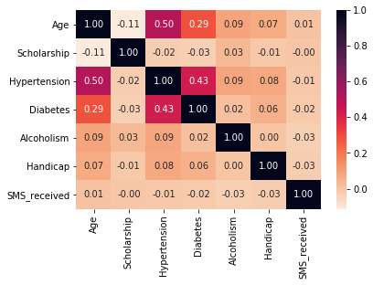

```python
stats_corr=['Age','Scholarship','Hypertension','Diabetes','Alcoholism','Handicap','SMS_received']
ax=sns.heatmap(df[stats_corr].corr(),annot=True,fmt='.2f',cmap='rocket_r');
bottom, top = ax.get_ylim()
ax.set_ylim(bottom + 0.5, top - 0.5);
```

### Research Question 1: What is the Showup vs No Showup appointment statistics?

```python
y=df['No_show'].value_counts()
y
```

```
Yes    85307
No     21675
Name: No_show, dtype: int64
```

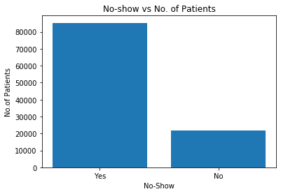

```python
ind=['Yes','No']
plt.bar(ind,y);
plt.xlabel('No-Show');
plt.ylabel('No.of Patients');
plt.title("No-show vs No. of Patients");
```

#### Based on the above graph, we can say that:

> More number of patients showed up for appointment.

#### a function to calculate the percentage :

```python
def calc_percent(count,total):
    return ((count/total)*100)
```

### Research Question 2: How Scholarship variable affects the No show of the Appointments?

```python
#Dataframe of the Patients with scholarship
df_scholar=df[df['Scholarship']==1]
height=df_scholar['No_show'].value_counts()

#Dataframe of the Patients without scholarship
df_scholar=df[df['Scholarship']==0]
hei=df_scholar['No_show'].value_counts()

print("No. of Patients with scholarship and showed up: {}".format(height[0]))
print("No. of Patients without scholarship and showed up: {}".format(hei[0]))
```

```
No. of Patients with scholarship and showed up: 8238
No. of Patients without scholarship and showed up: 77069
```

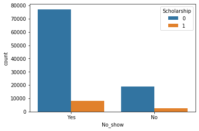

```python
sns.countplot(x='No_show',hue='Scholarship',data=df);
```

#### Based on the above graph, we can say that:

> Patients without scholarship showed up more for the appointment than the patients without scholarship.

#### Percentage of Patients showup for appointement with or without Scholarship

```python
scholar_count=df['Scholarship'].value_counts()
scholar=calc_percent(height[0],scholar_count[1])
noscholar=calc_percent(hei[0],scholar_count[0])
print("Percentage of patients with scholarship and showed up for appointment {} %".format(scholar))
print("Percentage of patients without scholarship and showed up for appointment {} %".format(noscholar))
```

```
Percentage of patients with scholarship and showed up for appointment 76.21426588953649 %
Percentage of patients without scholarship and showed up for appointment 80.1357969492477 %
```

### Research Question3: How 'Age' variable affects the Noshow for an appointment?

> For the Solution of the question I have divided the Age Groups as follows:  
> Division AgeGroup  
> Child [1-17]  
> Adult [18-60]  
> Old [61-above]

```python
  #Child Dataframe- Age[1-17]
child=df[df['Age']<18]
child_no=child[child['No_show']=='No']['Age'].value_counts().sum()
child_yes=child[child['No_show']=='Yes']['Age'].value_counts().sum()

  #Adult Dataframe- Age[18-60]
ad=df[(df['Age']>=18) & (df['Age']<=60)]
ad_no=ad[ad['No_show']=='No']['Age'].value_counts().sum()
ad_yes=ad[ad['No_show']=='Yes']['Age'].value_counts().sum()

  #Old Aged Dataframe-  Age[61-above]
old=df[df['Age']>60]
old_no=old[old['No_show']=='No']['Age'].value_counts().sum()
old_yes=old[old['No_show']=='Yes']['Age'].value_counts().sum()
```

#### Visualisation of the affect of Age on Noshow of the Appointment

```
Percentage of Adults patients showed up 78.9956138966899%
Percentage of Old aged patients showed up 84.79327969232327%
Percentage of Child patients showed up 77.52841981626746%
```

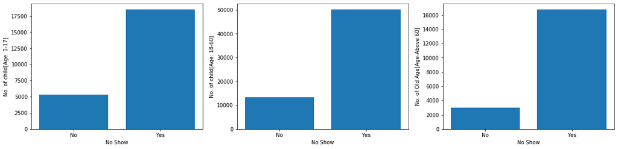

```python
fig=plt.figure(figsize=(20,15))
plt.subplot(331)
plt.bar(x=['No','Yes'],height=[child_no,child_yes])
plt.xlabel("No Show")
plt.ylabel("No. of child[Age: 1-17]")
plt.subplot(332)
plt.bar(x=['No','Yes'],height=[ad_no,ad_yes])
plt.xlabel("No Show")
plt.ylabel("No. of child[Age: 18-60]")
plt.subplot(333)
plt.bar(x=['No','Yes'],height=[old_no,old_yes])
plt.xlabel("No Show")
plt.ylabel("No. of Old Age[Age-Above 60]")

per_ad= calc_percent(ad_yes,len(ad)) #(ad_yes/len(ad))*100
per_old=calc_percent(old_yes,len(old))#(old_yes/len(old))*100
per_child=calc_percent(child_yes,len(child))#(child_yes/len(child))*100
print("Percentage of Adults patients showed up {}%".format(per_ad))
print("Percentage of Old aged patients showed up {}%".format(per_old))
print("Percentage of Child patients showed up {}%".format(per_child))
```

#### Based on the above graph, we can say that:

> Adult patients are more as compared to Children and Old aged patients.

### Research Question4: How the variables 'Hypertension','Diabetes','Alcoholism','Handicap' affect Noshow for an appointment?

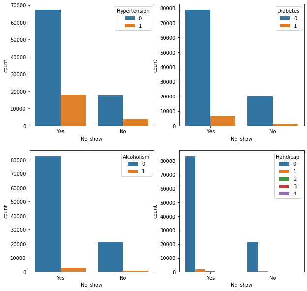

```python
conditions=['Hypertension','Diabetes','Alcoholism','Handicap']
fig=plt.figure(figsize=(10,10))
for i, var in enumerate(conditions):
    ax=fig.add_subplot(2,2,i+1)
    sns.countplot(x='No_show',hue=var,data=df)
```

#### Based on the above subplots, we can say that:

> There are more patients with Hypertension, when compared to Diabetes,Alcoholism and Handicap.

```python
hyper_yes=(df['Hypertension']==1).value_counts()[1]
hypertension=df[df['Hypertension']==1]['No_show'].value_counts()[0]
print("Out of total people having hypertension, {} % of People showed up for appointment.".format(calc_percent(hypertension,hyper_yes)))
```

```
Out of total people having hypertension, 82.69804137424889 % of People showed up for appointment.
```

```python
diab_yes=(df['Diabetes']==1).value_counts()[1]
diabetes=df[df['Diabetes']==1]['No_show'].value_counts()[0]
print("Out of total people having Diabetes, {} % of People showed up for appointment.".format(calc_percent(diabetes,diab_yes)))
```

```
Out of total people having Diabetes, 81.99672667757774 % of People showed up for appointment.
```

```python
alc_yes=(df['Alcoholism']==1).value_counts()[1]
alcoholism=df[df['Alcoholism']==1]['No_show'].value_counts()[0]
print("Out of total people having Alcoholism, {} % of People showed up for appointment.".format(calc_percent(alcoholism,alc_yes)))
```

```
Out of total people having Alcoholism, 79.85119047619048 % of People showed up for appointment.
```

### Research Question5: How the SMS_recieved variable affect the Noshow of an appointment?

```python
df_sms=df[df['SMS_received']==1]
h_sms=df_sms['No_show'].value_counts()

df_sms=df[df['SMS_received']==0]
h=df_sms['No_show'].value_counts()

print("No. of Patients recieved SMS and showed up: {}".format(h_sms[0]))
print("No. of Patients not recieved SMS and showed up: {}".format(h[0]))
```

```
No. of Patients recieved SMS and showed up: 25017
No. of Patients not recieved SMS and showed up: 60290
```

```python
sms_val=df['SMS_received'].value_counts()
sms=calc_percent(h_sms[0],sms_val[1])
nosms=calc_percent(h[0],sms_val[0])
print("Percentage of people showed up for appointment with sms recieved is {}%".format(sms))
print("Percentage of people showed up for appointment with no sms recieved is {}%".format(nosms))
```

```
Percentage of people showed up for appointment with sms recieved is 72.33482723724158%
Percentage of people showed up for appointment with no sms recieved is 83.2769313645593%
```

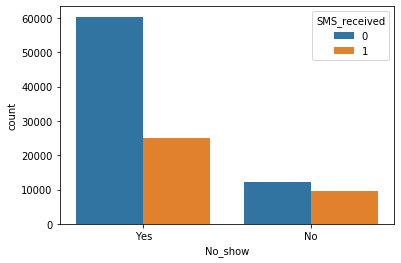

```python
sns.countplot(x='No_show',hue='SMS_received',data=df);
```

#### Based on the above graph, we can say that:

> Patients who didnot recieved SMS showed up more than the people who recieved the SMS

### Research Question 6: How the Gender variable affect on the Noshow of an appointment?

```python
# Total Male and Female Count
df['Gender'].value_counts()
```

```
F    70115
M    36867
Name: Gender, dtype: int64
```

```python
df_fem=df[df['Gender']=='F']
val_fem=df_fem['No_show'].value_counts()
print("No. of Females showed up for appointment are: {}".format(val_fem[0]))
print("No. of Females not showed up for appointment are: {}".format(val_fem[1]))
```

```
No. of Females showed up for appointment are: 55843
No. of Females not showed up for appointment are: 14272
```

```python
df_m=df[df['Gender']=='M']
val_m=df_m['No_show'].value_counts()
print("No. of males showed up for appointment are: {}".format(val_m[0]))
print("No. of males not showed up for appointment are: {}".format(val_m[1]))
```

```
No. of males showed up for appointment are: 29464
No. of males not showed up for appointment are: 7403
```

#### Visualisation of the Gender vs Noshow

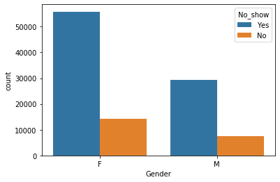

```python
sns.countplot(x='Gender',hue='No_show',data=df);
```

#### Based on the above graph we can say that:

> Total number of feamles are more than males, but both genders showed up in same ratio.

### Research Question 7: How the variable 'Awaited_days' affect on the Noshow for an appointment?

```python
# No. of days awaited for the Appointment Date from the Scheduled Date
df['awaited_days'].value_counts().sort_index()
```

```
0      37154
1       5028
2       6636
3       2639
4       5212
       ...
155       10
162       11
169        8
176       16
179       10
Name: awaited_days, Length: 129, dtype: int64
```

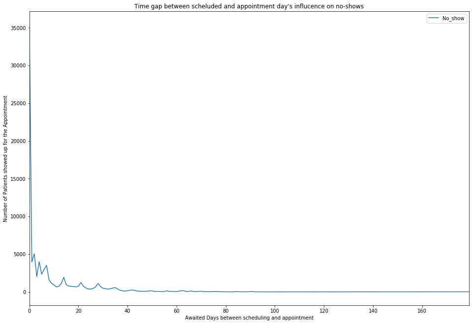

```python
df_yes=df[df['No_show']=='Yes']
df_days = df_yes[['No_show', 'awaited_days']].groupby('awaited_days').count()
df_days.plot(kind='line', figsize=(16,11));
plt.title("Time gap between scheluded and appointment day's influcence on no-shows");
plt.xlabel('Awaited Days between scheduling and appointment')
plt.ylabel('Number of Patients showed up for the Appointment');
```

#### Based on the above line chart, we could see that:

> Less the number of awaiting days, more the Number of Patients show up for the appointment.  
> As the number of awaiting days increase beyond 40 the graph becomes consistent.

## Conclusions

> 1. Out of total patients: Patients showed up for the Appointment are 85307 and patients did not showed up are 21675.
> 2. We can see that Brazilian Welfare Scholarship does not shows a positive trend on no-shows for the Appointment  
>    Percentage of patients with scholarship and showed up for appointment 76 %  
>    Percentage of patients without scholarship and showed up for appointment 80 %
> 3. Out of total Old aged Patients 84% of the patients showed up for the appointment whereas 78.9% of the Adults showed up and 77.5% of children showed up.

> 4.Out of total patients who did not recieved the SMS 83% of patient showed up, whereas Out of total patients who recieved SMS only 72% of patient showed up.(This looks opposite to what usually happens. People who do receive a reminder SMS usually tend to visit the hospital more than those who haven't received an SMS. Or this could be an SMS that was recived while booking an appointment and could possibly have no correlation with the visit probability.)

> 8.On the basis of the line graph of No. of Awaited Days for appointment and No. of Patients showed up, its known that more number of people showup for the appointment when they get the appointment for less number of awaiting days.

## References

> 1.https://matplotlib.org/api/pyplot_api.html : Used for plotting the graphs  
> 2.https://seaborn.pydata.org/generated/seaborn.countplot.html : used for Countplot graphs  
> 3.https://docs.scipy.org/doc/numpy/reference/arrays.datetime.html : Used in cleaning the dataset